# Vehicles on the road

How many unique id’s are being used every day? This should give us an idea of the amount of vehicles being used.

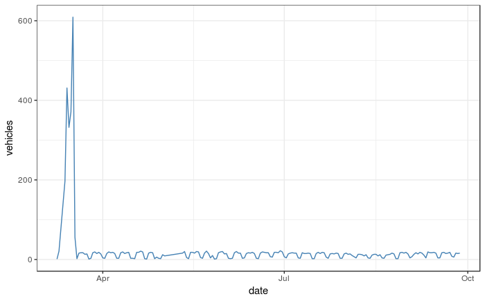

# Signals measured

When we look at the number of signals measured, it becomes clear what data is mostly measured:

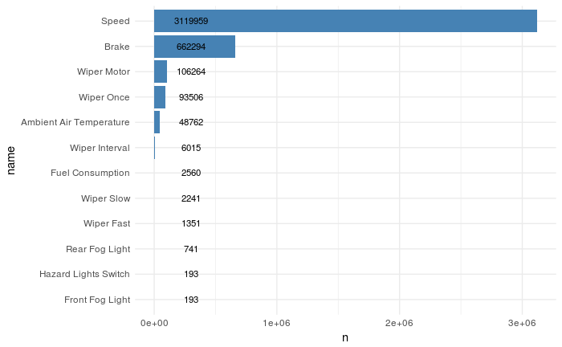

Obviously, the large majority of measurements consists of *speed* and *brake* measurements since a new speed is record on every change of roughly 5km/h and the brake is often used. However, to put this data into better perspective, we should also look at how long some of the actors were used. For instance, a slow wiper may be turned on once but still being used for more than an hour, thus giving an underestimation of how long it has been used. Therefore we will later check for the boolean (on/off) signals over what distance and what time interval they have been used.

# GPS updates

One striking feature of this canbus dataset is that the same GPS position is used for multiple measurements, even with speed measurements. The followin graph shows the amount of measurements per unique GPS position.

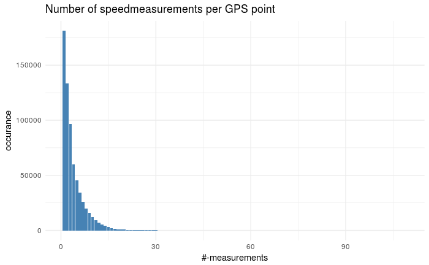

As you can see more than half of the GPS points have more than 1 speedmeasurement attached to it. There are even (rare) cases where more 50 measurements are attributed to the same GPS position. This is strange, because the GPS has a high precision (as can be seen in later plots) and is likely keeping a constant tracking signal.